# Data Science for Public Policy

Assignment 04

Author

Ruiyang Zhang - rz326; Xiangming Zeng - xz634; Xiaorui Shi - xs215

## Source of Data

[Quality of Government Basic Dataset (2023)](https://www.gu.se/en/quality-government/qog-data/data-downloads/basic-dataset)

## Libraries

```r
library(tidyverse)
library(haven)
```

## Data preparation

```r
qog <- read_dta("data/idm_qog.dta")
qog <- qog %>%
  select(year,
         country_name = cname,
         gdp_per_capita = gle_cgdpc,
         democracy = chga_demo,
         transparency_index = diat_ti,
         new_busi_density = wdi_busden,
         level_of_democracy = ht_ipolity2
         )
```

## Exercise 03

The message says “The following paths are ignored by one of your .gitignore files: data”

## Exercise 04: Data visualization

### Why democracies have better economic performance? One explanation

**The Story:** The distribution of wealth is extremely unequal. Most countries are poor, while few are rich. However, democracies exhibit significantly higher economic performance than autocracies. What is the mechanism behind this difference? This study proposes one possible explanation: democracies feature high information transparency, which can reduce corruption and improve the business environment. Consequently, enterprises find it easier to emerge and grow in democracies compared to autocracies.

### The global distribution of GDP per capita

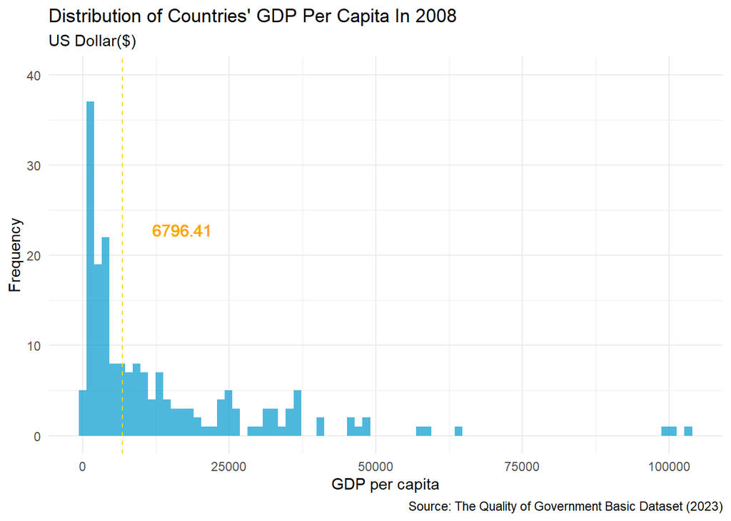

```r
qog_2008 <- qog %>%
  filter(year == 2008)

median_x <- median(qog_2008$gdp_per_capita, na.rm = TRUE)

qog %>%
  filter(year == 2008) %>%
  ggplot(aes(gdp_per_capita)) +
  geom_histogram(bins = 80,fill = "deepskyblue3", alpha = 0.7) +
  geom_vline(
    xintercept = median_x,
    color = "gold",
    linetype = "dashed") +
  geom_text(
    aes(x = median_x, y = 0, label = round(median_x, 2)),
    hjust = -0.5,
    vjust = -16,
    color = "orange",
    size = 4
  ) +
  theme_minimal() +
  scale_y_continuous(limits = c(0, 40)) +
  labs(
    title = "Distribution of Countries' GDP Per Capita In 2008",
    subtitle = "US Dollar($)",
    y = "Frequency",
    x = "GDP per capita",
    caption = "Source: The Quality of Government Basic Dataset (2023)"
  )
```

As shown in this histogram, there is a wide range of GDP per capita among countries, ranging from almost zero to more than 100,000. Additionally, the histogram is severely right-skewed, with half of the countries having a GDP per capita lower than $6796.41 in 2008. This indicates that the majority of countries are poor, while only a few are considered wealthy.

### The difference of GDP per capita between two political systems

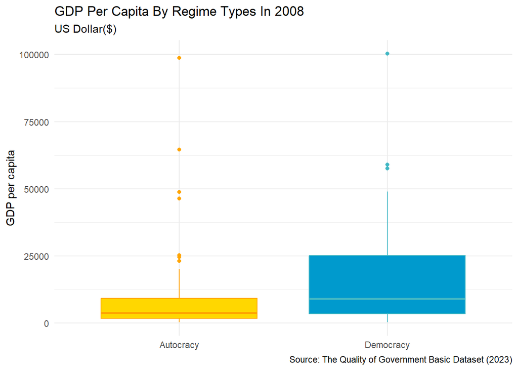

```r
qog %>%
  filter(year == 2008) %>%
  mutate(chrdemo = case_when(
    democracy == 0 ~ "Autocracy",
    democracy == 1 ~ "Democracy")) %>%
  filter(chrdemo != is.na(chrdemo)) %>%
  ggplot(aes(chrdemo, gdp_per_capita)) +
  geom_boxplot(aes(fill = chrdemo, color = chrdemo)) +
  theme_minimal() +
  scale_fill_manual(values = c( "gold", "deepskyblue3")) +
  scale_color_manual(values = c( "orange", "#41B7C4")) +
  labs(
    title = "GDP Per Capita By Regime Types In 2008",
    subtitle = "US Dollar($)",
    y = "GDP per capita",
    caption = "Source: The Quality of Government Basic Dataset (2023)"
  ) +
  theme(
    legend.position = "none",
    axis.title.x = element_blank()
    )
```

### The relationship between democracy and transparency

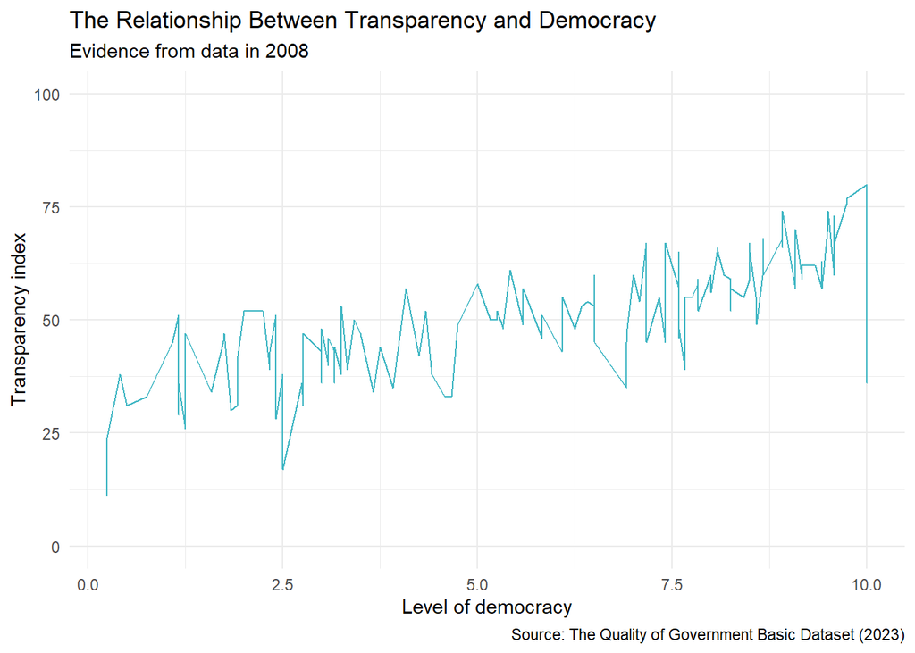

```r
qog %>%
  filter(year == 2008) %>%
  ggplot(aes(x = level_of_democracy)) +
  geom_line(aes(y = transparency_index), color = "#41B7C4") +
  scale_y_continuous(limits = c(0,100)) +
  theme_minimal() +
  labs(
  title = "The Relationship Between Transparency and Democracy",
       subtitle = "Evidence from data in 2008",
       x = "Level of democracy",
       y = "Transparency index",
       caption = "Source: The Quality of Government Basic Dataset (2023)")
```

This line chart shows that as the level of democracy increases, the transparency index of countries also increases, although there are some degrees of variation. In other words, democracy has a positive correlation with information transparency. This relationship may be due to open and competitive political processes, freedom of speech, the rule of law, and civil society.

### The relationship between transparency and entrepreneurship

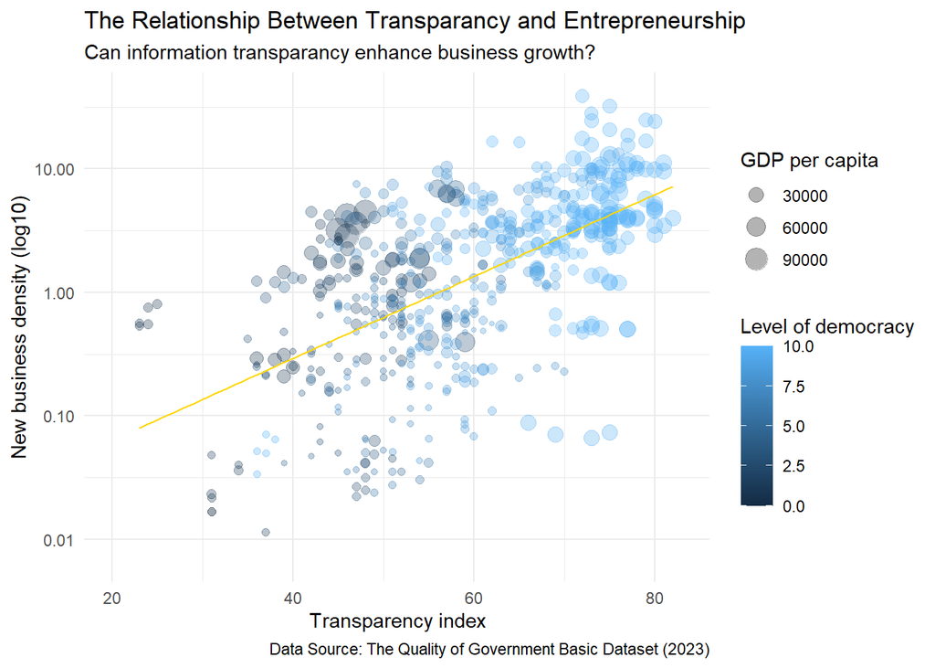

```r
qog %>% ggplot(aes(x = transparency_index, y = new_busi_density)) +
  geom_point(aes(color = level_of_democracy, size = gdp_per_capita),
             alpha = 0.3
             ) +
  geom_smooth(method = "lm", se = FALSE, size = 0.5, color = "gold") +
  scale_y_log10() +
  scale_x_continuous(limits = c(20,NA)) +
  xlab("Transparency index") +
  ylab("New business density (log10)") +
  labs(title = "The Relationship Between Transparancy and Entrepreneurship",
       subtitle = "Can information transparancy enhance business growth?",
       caption = "Data Source: The Quality of Government Basic Dataset (2023)") +
  labs(color = "Level of democracy", size = "GDP per capita") +
  theme(
    legend.key = element_blank(),
    legend.key.size = unit(0.45, "cm")
  ) +
  theme_minimal()
```

### Policy Relevance

Therefore, to improve the performance of the developing world and reduce the global socioeconomic inequality, one possible way is supporting the establishment of robust democratic systems among developing countries. However, for countries where autocratic systems are entrenched, one more realistic way is to leverage the influence of international organizations to increase the transparency level of those countries.